# Using Data from Custom Sources

Jack Taylor

The built-in variables of LexOPS are useful but not exhaustive. Thankfully, LexOPS can work with any suitable list of features. For this example, we will join the [Lancaster Sensorimotor norms](https://osf.io/7emr6/) to [Engelthaler and Hills’ humour ratings](https://github.com/tomasengelthaler/HumorNorms), and the in-built LexOPS dataset (`LexOPS::lexops`). We can then use this to generate stimuli with a visual rating by humour interaction, controlling for length and frequency.

# Packages

```r
library(readr)
library(dplyr)
library(ggplot2)
library(LexOPS)
```

# Importing Datsets

## Importing Sensorimotor Norms

The Lancaster Sensorimotor Norms are available from the [OSF page](https://osf.io/48wsc/).

```r
sensorimotor <- read_csv("https://osf.io/48wsc/download")
```

Let’s have a quick peak at the data.

```r
sensorimotor %>%
  head(5)
```

| Word | Auditory.mean | Gustatory.mean | Haptic.mean | Interoceptive.mean | Olfactory.mean | Visual.mean | Foot_leg.mean | Hand_arm.mean | Head.mean | Mouth.mean | Torso.mean | Auditory.SD | Gustatory.SD | Haptic.SD | Interoceptive.SD | Olfactory.SD | Visual.SD | Foot_leg.SD | Hand_arm.SD | Head.SD | Mouth.SD | Torso.SD | Max_strength.perceptual | Minkowski3.perceptual | Exclusivity.perceptual | Dominant.perceptual | Max_strength.action | Minkowski3.action | Exclusivity.action | … |
| --- | --- | --- | --- | --- | --- | --- | --- | --- | --- | --- | --- | --- | --- | --- | --- | --- | --- | --- | --- | --- | --- | --- | --- | --- | --- | --- | --- | --- | --- | --- |
| A | 2.214286 | 0.0000000 | 0.4285714 | 0.0000000 | 0.0000000 | 2.428571 | 0.0000000 | 0.3571429 | 1.071429 | 0.3571429 | 0.0000000 | 2.259291 | 0.0000000 | 0.9376145 | 0.0000000 | 0.0000000 | 2.408775 | 0.0000000 | 1.336306 | 2.129077 | 1.3363062 | 0.0000000 | 2.428571 | 2.934085 | 0.4788732 | Visual | 1.071429 | 1.097256 | 0.6000000 | … |
| A CAPPELLA | 4.333333 | 0.0000000 | 0.2222222 | 0.7222222 | 0.0000000 | 1.666667 | 0.3809524 | 0.4285714 | 2.714286 | 3.7142857 | 1.0000000 | 1.608799 | 0.0000000 | 0.5483189 | 1.3636265 | 0.0000000 | 1.909727 | 0.9734573 | 1.075706 | 1.901128 | 1.8477786 | 1.4491377 | 4.333333 | 4.420628 | 0.6240000 | Auditory | 3.714286 | 4.167341 | 0.4046243 | … |
| AARDVARK | 1.625000 | 0.5625000 | 1.6250000 | 0.0625000 | 1.2500000 | 4.125000 | 0.1764706 | 0.7058824 | 2.235294 | 0.0588235 | 0.0588235 | 1.784190 | 1.2632630 | 1.9278658 | 0.2500000 | 1.8797163 | 1.258306 | 0.5285941 | 1.311712 | 1.921244 | 0.2425356 | 0.2425356 | 4.125000 | 4.325018 | 0.4391892 | Visual | 2.235294 | 2.258902 | 0.6727273 | … |
| ABACK | 1.294118 | 0.0588235 | 0.2941176 | 1.3529412 | 0.0000000 | 2.823529 | 0.0000000 | 0.0000000 | 3.272727 | 0.3636364 | 0.1818182 | 1.896204 | 0.2425356 | 0.9851844 | 1.8007351 | 0.0000000 | 2.007340 | 0.0000000 | 0.000000 | 1.902152 | 0.9244163 | 0.6030227 | 2.823529 | 3.006634 | 0.4848485 | Visual | 3.272727 | 3.274410 | 0.8571429 | … |
| ABACUS | 1.555556 | 0.1666667 | 3.7222222 | 0.2777778 | 0.1111111 | 3.944444 | 0.0000000 | 2.4736842 | 2.631579 | 0.1052632 | 0.0000000 | 1.616904 | 0.5144958 | 1.4061025 | 0.6691132 | 0.4714045 | 1.304843 | 0.0000000 | 2.269812 | 2.191157 | 0.3153018 | 0.0000000 | 3.944444 | 4.887248 | 0.3920455 | Visual | 2.631579 | 3.219225 | 0.5050505 | … |

## Importing Humour Norms

The Humour Norms are available from the [Github Page](https://github.com/tomasengelthaler/HumorNorms).

```r
humour <- read_csv("https://raw.githubusercontent.com/tomasengelthaler/HumorNorms/master/humor_dataset.csv")
```

Let’s have a look at this data too.

```r
humour %>%
  head(5)
```

| word | mean | sd | n | mean_M | sd_M | n_M | mean_F | sd_F | n_F | mean_young | sd_young | n_young | mean_old | sd_old | n_old |
| --- | --- | --- | --- | --- | --- | --- | --- | --- | --- | --- | --- | --- | --- | --- | --- |
| abbey | 2.292683 | 1.1455109 | 41 | 2.176471 | 1.3800043 | 17 | 2.347826 | 0.9820524 | 23 | 2.391304 | 1.1961731 | 23 | 2.166667 | 1.098127 | 18 |
| abode | 2.413793 | 1.1185846 | 29 | 2.100000 | 0.9944289 | 10 | 2.578947 | 1.1697953 | 19 | 2.692308 | 1.1821319 | 13 | 2.187500 | 1.046821 | 16 |
| abscess | 1.593750 | 1.0429293 | 32 | 1.625000 | 1.1877349 | 8 | 1.583333 | 1.0179548 | 24 | 1.555556 | 1.0416176 | 18 | 1.642857 | 1.081818 | 14 |
| absence | 1.640000 | 0.9521905 | 25 | 1.615385 | 0.9607689 | 13 | 1.666667 | 0.9847319 | 12 | 1.571429 | 0.8516306 | 14 | 1.727273 | 1.103713 | 11 |
| abstract | 2.411765 | 1.2819882 | 34 | 1.933333 | 1.0327956 | 15 | 2.789474 | 1.3572418 | 19 | 2.421053 | 1.1212983 | 19 | 2.400000 | 1.502379 | 15 |

# Joining Data Together

```r
sensorimotor <- sensorimotor %>%
  rename(word = Word) %>%
  mutate(word = tolower(word))
```

Next, we will prefix all the features from the humour norms with “Humour.”, so they will be easily identifiable in the final dataset. We can use `rename_at()` and `vars(-word)` to add this prefix to all columns except the `word` column.

```r
humour <- humour %>%
  rename_at(vars(-word), ~paste("Humour", .x, sep="."))
```

Joining the data together is then easy with the [dplyr join functions](https://dplyr.tidyverse.org/reference/join.html). Here we use `full_join()`, joining by the common column `"word"`. Finally, we join the data to the `lexops` in-built dataset, as this contains features we can use to control for length and frequency. Since the words are stored in `lexops` in the `string` column, we tell `left_join()` that these columns should be treated as the same thing, with `c("word"="string")`.

```r
sens_hum <- full_join(sensorimotor, humour, by="word") %>%
  left_join(lexops, by=c("word"="string"))
```

# Generating Stimuli

Before we choose boundaries for our splits, we want to check the distributions of our independent variables.

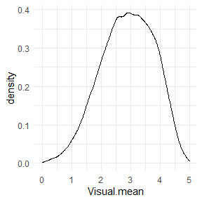

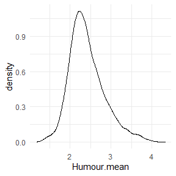

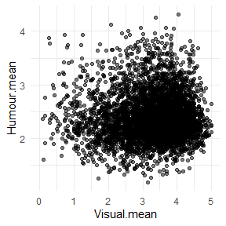

```r
sens_hum %>% ggplot(aes(Visual.mean)) + geom_density()
sens_hum %>% ggplot(aes(Humour.mean)) + geom_density()
sens_hum %>% ggplot(aes(Visual.mean, Humour.mean)) + geom_point(alpha=0.5)
```

Finally, we can generate stimuli with our new words. We will create two levels of Visual ratings: `0:2` (low) and `3.5:5` (high), and two levels of Humour ratings: `2:2.5` (neutral, as consistently low humour ratings are often tabboo) and `3:5` (high). We’ll control for word length exactly, and word frequency within a tolerance of `-0.2:0.2`.

Since we’re using our own data, we need to use the `set_options()` function to tell LexOPS which column contains our unique identifier, i.e., our words (`id_col = "word"`).

```r
stim <- sens_hum %>%
  set_options(id_col = "word") %>%
  split_by(Visual.mean, 0:2 ~ 3.5:5) %>%
  split_by(Humour.mean, 2:2.5 ~ 3:5) %>%
  control_for(Length, 0:0) %>%
  control_for(Zipf.SUBTLEX_UK, -0.2:0.2) %>%
  generate(25)
```

```
## Generated 1/25 (4%). 2 total iterations, 0.50 success rate.
Generated 2/25 (8%). 5 total iterations, 0.40 success rate.
Generated 4/25 (16%). 8 total iterations, 0.50 success rate.
Generated 5/25 (20%). 9 total iterations, 0.56 success rate.
Generated 6/25 (24%). 11 total iterations, 0.55 success rate.
Generated 8/25 (32%). 16 total iterations, 0.50 success rate.
Generated 9/25 (36%). 17 total iterations, 0.53 success rate.
Generated 10/25 (40%). 18 total iterations, 0.56 success rate.
Generated 11/25 (44%). 19 total iterations, 0.58 success rate.
Generated 12/25 (48%). 21 total iterations, 0.57 success rate.
Generated 14/25 (56%). 29 total iterations, 0.48 success rate.
Generated 15/25 (60%). 30 total iterations, 0.50 success rate.
Generated 16/25 (64%). 31 total iterations, 0.52 success rate.
Generated 18/25 (72%). 43 total iterations, 0.42 success rate.
Generated 19/25 (76%). 44 total iterations, 0.43 success rate.
Generated 20/25 (80%). 59 total iterations, 0.34 success rate.
Generated 21/25 (84%). 60 total iterations, 0.35 success rate.
Generated 22/25 (88%). 62 total iterations, 0.35 success rate.
Generated 24/25 (96%). 71 total iterations, 0.34 success rate.
Generated 25/25 (100%). 72 total iterations, 0.35 success rate.
```

We can view a quick summary of our stimuli with the `plot_design()` function.

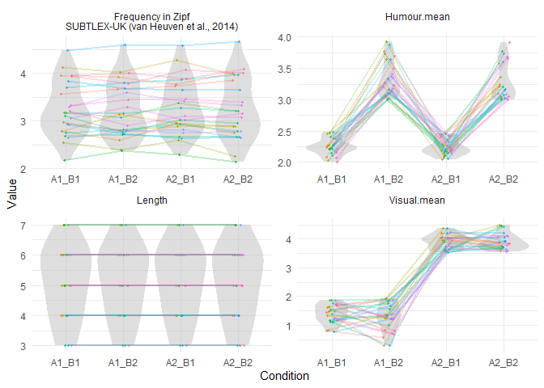

```r
plot_design(stim)
```

Here is the list of stimuli generated for the design of visual sensorimotor ratings (A: A1 low, A2 high) by humour ratings (B: B1 low, B2 high), controlling for word length and frequency.

```r
print(stim)
```

| item_nr | A1_B1 | A1_B2 | A2_B1 | A2_B2 | match_null |
| --- | --- | --- | --- | --- | --- |
| 1 | palate | jingle | fossil | jockey | A2_B1 |
| 2 | myth | toot | cart | muck | A1_B1 |
| 3 | adage | toots | valet | husky | A2_B1 |
| 4 | shriek | gargle | tropic | hippie | A2_B2 |
| 5 | roar | tart | pope | cock | A1_B1 |
| 6 | rebirth | bullion | workman | nightie | A1_B1 |
| 7 | cervix | jabber | dosage | tassel | A1_B2 |
| 8 | titan | oomph | ledge | crumb | A2_B2 |
| 9 | menthol | ragtime | hacksaw | playpen | A2_B1 |
| 10 | sinus | nymph | sedan | dildo | A1_B2 |
| 11 | nag | gab | fad | hoe | A2_B2 |
| 12 | ringer | humbug | thesis | squint | A1_B1 |
| 13 | omen | whim | mesh | boob | A1_B2 |
| 14 | hymn | oink | pale | piss | A2_B1 |
| 15 | fathom | ramble | vandal | sundae | A1_B2 |
| 16 | tune | joke | bike | shit | A1_B2 |
| 17 | rap | wit | ore | bra | A2_B2 |
| 18 | relapse | stinker | forceps | twosome | A2_B1 |
| 19 | downer | holler | slouch | sphinx | A2_B1 |
| 20 | ballad | squawk | almond | weasel | A2_B1 |
| 21 | gamma | clunk | bathe | pooch | A2_B2 |
| 22 | angst | fluke | lilac | groin | A2_B2 |
| 23 | chant | whiff | vomit | whore | A1_B1 |
| 24 | notion | squeak | helmet | muffin | A1_B1 |
| 25 | gut | moo | ski | ass | A1_B2 |

# Citing Sources

The `cite_design()` function is useful for suggesting papers that you should cite having generated your stimuli. Note that for variables LexOPS does not know, while the variable will be suggested as something that needs citing, you will have to find the citation yourself.

```r
cite_design(stim)
```

```
## Please also cite LexOPS: Taylor, Beith and Sereno (2020), http://doi.org/10.3758/s13428-020-01389-1
```

| var | measure | source | url |
| --- | --- | --- | --- |
| Visual.mean | Custom Measure | Custom Source | Unknown |
| Humour.mean | Custom Measure | Custom Source | Unknown |
| Length | Length (Number of Characters) | NA | NA |
| Zipf.SUBTLEX_UK | Frequency in Zipf (Zipf=log10(frequency per million)+3) | SUBTLEX-UK (van Heuven, Mandera, Keuleers, & Brysbaert, 2014) | https://doi.org/10.1080/17470218.2013.850521 |